# HW2

## Домашнее задание 2. Работа с Pymol.

### Горохов Никита

```python
from xmlrpclib import ServerProxy
from IPython.display import Image, display
import os, sys
```

```python
import __main__

__main__.pymol_argv = [ 'pymol', '-cp' ]

import pymol

pymol.finish_launching()

from pymol import cmd
```

### Основное задание

1) Оцените возможности *Sculpting*, в *Wizard*->*Demo*->*Sculpting*  
Оценил)

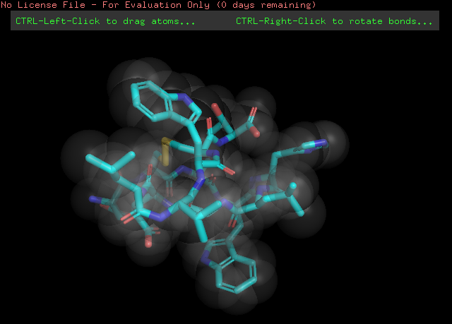

```python
Image(filename="sculpting.png")
```

2) Используюя **select within** найдите водородные связи которыми белок связывает лиганд. Опишите эти возможные другие взаимодействия белка с лигандом. Попробуйте поискать альтернативный способ поиска водородных связей.

```python
cmd.fetch("1LMP")
```

```
'1LMP'
```

```python
cmd.do('''
remove solvent
show cartoon
select ligand, hetatm
show sticks, ligand
distance hbonds, all, ligand, 5, mode=2
zoom ligand
png hbond.png
''')
```

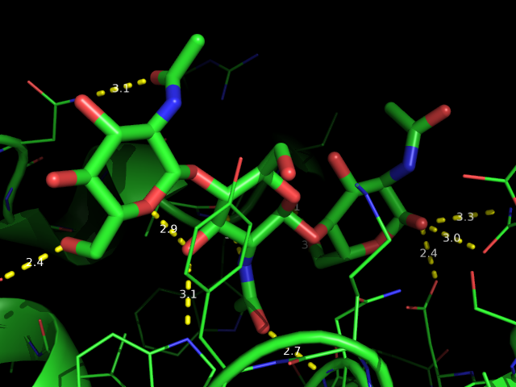

```python
Image(filename="hbond.png")
```

3) Средствами Tcl/Tk интерфейса **Wizard->Mutagenesis** проведите мутацию в белке, которая по вашему мнению должна привести к потере связывания с лигандом.  
TYR62 (CA) -> LEU

```python
aminoacid = 'resi 62'
cmd.wizard('mutagenesis')
cmd.do('''
label resi 62 and name CA, "(%s, %s)" % (resn, resi)
cmd.get_wizard().do_select("resi 62")
cmd.get_wizard().set_mode("LEU")
cmd.get_wizard().apply()
cmd.set_wizard()
save 1lmp_mutation.pdb
''')
```

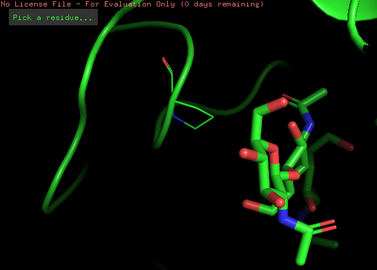

```python
Image(filename="mut.png")
```

Используя команды **mset, mview, super, translate** создайте анимационный ролик mpeg где происходит совмещение белков и показывается место мутации.  
Содержимое скрпита *my_script.pml* представлено ниже

```python
cmd.do('''
reinitialize
load 1lmp.pdb
load 1lmp_mutation.pdb

remove solvent
select ligand1, hetatm AND 1lmp
select ligand2, hetatm AND 1lmp_mut
select target1, resi 62 and 1lmp
select target2, resi 62 and 1lmp_mut
label target1 AND name N, ("%s, %s:%s") % ("1lmp", resn, resi)
label target2 AND name O, ("%s, %s:%s") % ("1lmp_mut", resn, resi)
color palegreen
show cartoon
color lightblue, ligand1
color cyan, ligand2
color paleyellow, target1
color salmon, target2
show lines, target1 OR target2
set line_width, 2.5
disable target2
zoom


mset 1 x300

add_rock(12,179.99,axis='x',start=101, end=300)

frame 1
super 1lmp, 1lmp_mut
mview store
mview store, object=1lmp
mview store, object=1lmp_mut

frame 100
center target1
origin target1
zoom target1
mview store
mview store, object=1lmp
mview store, object=1lmp_mut


frame 200
zoom target1
mview store
mview store, object=1lmp
mview store, object=1lmp_mut

frame 1
mplay
''')
```

```python
from IPython.display import HTML, display

display(HTML("""
    <h2>
        Анимация
    </h2>
    <video alt="test" controls>
        <source src="HW2-video/animation.mp4" type="video/mp4">
    </video>
    """ ))
```

Анимация

[video not shown]

5) Приседените флуорусцентную метку *TAMRA* к белку через сложноэфирную связь. Используйте команды **fuse** и **torsion**.

```python
cmd.delete("all")
cmd.fetch("1lmp")
cmd.load("tamra.sdf")
cmd.png("tamra.png")
```

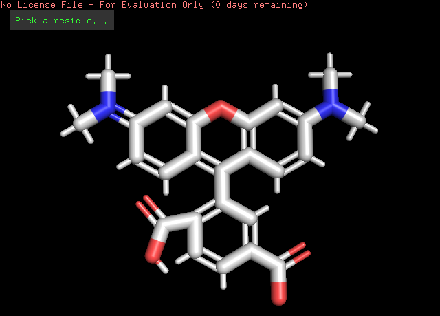

```python
Image(filename="tamra.png")
```

Необходимо выбрать мишени для присоеденения со стороны обоих молекул. Согласно [вики](https://ru.wikipedia.org/wiki/%D0%A1%D0%BB%D0%BE%D0%B6%D0%BD%D1%8B%D0%B5_%D1%8D%D1%84%D0%B8%D1%80%D1%8B), для образования сложноэфирной связи нужно выбрать *SER* или *TYR* или *THR*. А со стороны *TAMRA* нужно выбрать карбоксильную группу. С помощью **CTRL** + **колесико** я выбрал две точки

- You clicked /tamra///UNK`0/C -> (pk1)
- You clicked /1lmp/A/A/THR`43/CA -> (pk2)  
  После этого я применил команду **fuse** для соединения и **torsion** для поворота

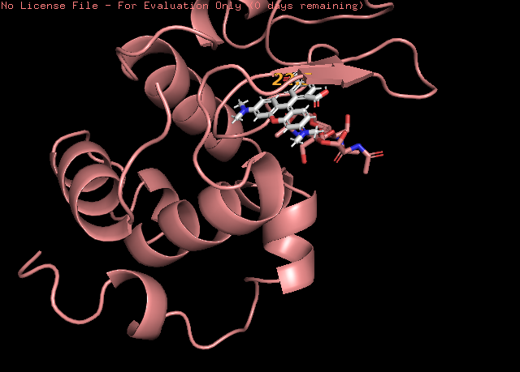

```python
Image(filename="connect.png")
```

6) Напишите скрипт для построения поли-аланиновой ( Вы вольны использовать любую аминоксилоту) альфа спирали длинной 100 аминкислот. Для начала найдем значения углов $\psi$ и $\phi$.  
Выберем $\phi = –57°, \psi = –47°$ ([Карты Рамачандрана](https://xn--n1afeh.xn--80abvyzg.xn--p1ai/%D0%BC%D0%BE%D0%BB%D0%B5%D0%BA%D1%83%D0%BB%D1%8B/%D0%A0%D0%B0%D0%BC%D0%B0%D1%87%D0%B0%D0%BD%D0%B4%D1%80%D0%B0%D0%BD.html))

```python
phi = -57
psi = -47
cmd.fragment ("ala")
for x in range(2, 101):
    cmd.edit("resi "+ str(x) +" and name C")
    editor.attach_amino_acid("pk1","ala")
    cmd.edit("resi "+ str(x) +" and name N", "resi "+ str(x) +" and name CA")
    cmd.torsion(phi)
    cmd.edit("resi "+ str(x) +" and name C", "resi "+ str(x) +" and name CA")
    cmd.torsion(psi)
python end
```

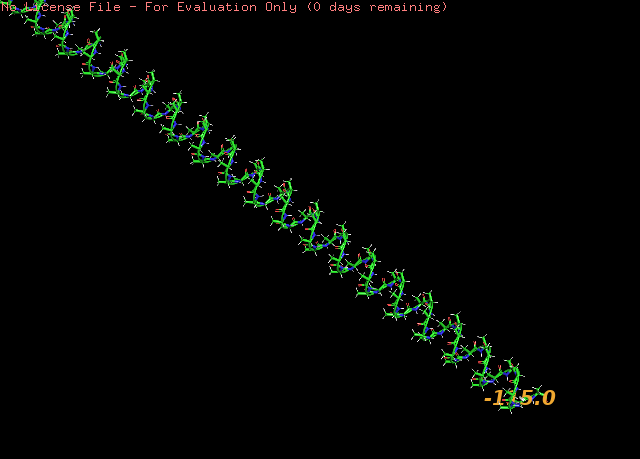

```python
Image(filename="poly.png")
```